# AJB2021_FVT_CEPF_S2

Robert L. Baker

12/29/2020

Abstract

This document includes links to an example dataset and code for employing an integral approach to function valued trait data.

#### Background and explanation

The data used here are from Li et al, 2020. “Epistatic Transcription Factor Networks Differentially Modulate Arabidopsis Growth and Defense” Genetics vol. 214 no. 2 529-541; https://doi.org/10.1534/genetics.119.302996.

The authors have time-series data on plant growth. When they model these data they find that the growth of different genotypes is best fit by different functions. Therefore, the FVT approach taken where a function is fit to data and parameters of that function are used “as data” won’t work because the functions are different."

Rather than using the parameters of an individual function “as data” we find the area under the curve described by each function and use that area “as data”.

It should be noted that the data used here are LS means for each day rather than replicate level data. Depending on the goal of the analysis, it is equally possible to find the area under the curve for individual replicates and then calculate LS means for the area under the curve.

```r
rm(list=ls()) #remove all objects from the R environment
gc() #can help return memory to R after large objects have been called.
```

```r
library(tidyverse)
library(readxl)
library(filesstrings)
```

#### Download the files, unzip & remove whitespace from filenames:

```r
#set working directory & load data:
#download zipped supplimental files at: https://gsajournals.figshare.com/ndownloader/files/20239863
#unzip files and set working directory to the folder "File S1" (or wherever you have saved the unzipped files)

remove_filename_spaces(replacement = "_") #replaces all whitespace in filenames with "_"
```

#### Load files and generate a new working dataframe.

The excel files contains 2 rectangles of data from separate growth chambers and these will need to be loaded separately.

```r
growth_CEF<-read_excel("Supplemental_Data_Set_1,_lsmeans_of_growth,_flowering_and_GLS_for_single_mutants.xlsx", range="B6:N27")
growth_CEF<-cbind("CEF", growth_CEF[,c(1,3:length(growth_CEF))])
colnames(growth_CEF)[1]<-"chamber"

growth_LSA<-read_excel("Supplemental_Data_Set_1,_lsmeans_of_growth,_flowering_and_GLS_for_single_mutants.xlsx", range="B32:N53")
growth_LSA<-cbind("LSA", growth_LSA[,c(1,3:length(growth_LSA))])
colnames(growth_LSA)[1]<-"chamber"

#generate a single dataframe with data from both growth chambers.
growth<-rbind(growth_CEF, growth_LSA)

#pull out growth data and store it as a list.
growth.list<-as.list(as.data.frame(t(growth[,4:13])))
```

#### Test case with graphical interpretation.

Here, we use just the first line of data to calculate the area under the curve, which we designate “diff”.

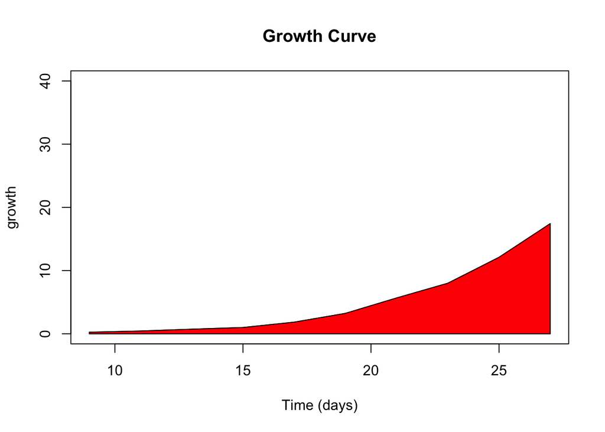

```r
y1<-growth.list$V1 #grab growth data from the first line of the data set
y2<-rep(0, length(y1)) #set a baseline, in this case zero (but you could also compare two functions)
x<-c(9,11,13,15,17,19,21,23,25,27) #x-axis time values that correspond to y-axis growth data; hard coded for simplicity

f1<-approxfun(x,y1-y2) #approximate the function of the relationship between growth and time
f2<-function(z)abs(f1(z)) #absolute value of the difference between the baseline value and the growth data in question. The absolute value doesn't make much difference with baseline of zero but might be important if you wanted to directly compare 2 genotypes whose growth function intersected at some point - or a single genotype in multiple environments with different growth functions that intersected.

plot(x,y1,type="l",ylim=c(0,40), ylab="growth", xlab="Time (days)", main="Growth Curve") #plot the estimated function

lines(x,y2,type="l",col="red") #plot the "baseline" value - zero in this case
polygon(c(x,rev(x)),c(y1,rev(y2)), col="red") #fit a polygon to the area between the function and the baseline: in this case the polygon represents the growth that the first individual underwent over time.
```

```r
diff<-integrate(f2,min(x),max(x)) #do some calculus to find the area of that polygon

diff
```

```
## 83.63555 with absolute error < 0.0038
```